# Case-Control Point Data Homework (Local Rates and Nearest Neighbors)

## c.

Perform a test for clustering using the q nearest neighbors method. Use $q=3,5,\ldots,19$ and $n_{sim}=499$ randomly labeled data sets. For which $q$ are there more cases than we would expect under random labeling in the q locations nearest each case? At what scale does this clustering appear to occur (use the contrasts)?

```r
# q nearest neighbor test
# use position in levels(grave$marks) to select case group
qnn.test(paracou,
         q = seq(3, 19, by = 2),
         nsim = 499,
         case = "adult")
```

```
adult has been selected as the case group
```

```
Q nearest neighbors test

case label:  adult
control label:  juvenile

Summary of observed test statistics

  q Tq pvalue
  3  9  0.306
  5 14  0.332
  7 18  0.406
  9 25  0.274
 11 32  0.194
 13 36  0.222
 15 42  0.202
 17 49  0.152
 19 54  0.154

Summary of observed contrasts between test statistics

  contrast Tcontrast pvalue
   T5 - T3         5  0.536
   T7 - T3         9  0.596
   T9 - T3        16  0.350
  T11 - T3        23  0.238
  T13 - T3        27  0.302
  T15 - T3        33  0.258
  T17 - T3        40  0.174
  T19 - T3        45  0.192
   T7 - T5         4  0.702
   T9 - T5        11  0.332
  T11 - T5        18  0.212
  T13 - T5        22  0.288
  T15 - T5        28  0.252
  T17 - T5        35  0.168
  T19 - T5        40  0.176
   T9 - T7         7  0.188
  T11 - T7        14  0.138
  T13 - T7        18  0.186
  T15 - T7        24  0.184
  T17 - T7        31  0.132
  T19 - T7        36  0.134
  T11 - T9         7  0.234
  T13 - T9        11  0.352
  T15 - T9        17  0.312
  T17 - T9        24  0.206
  T19 - T9        29  0.214
 T13 - T11         4  0.650
 T15 - T11        10  0.472
 T17 - T11        17  0.300
 T19 - T11        22  0.292
 T15 - T13         6  0.342
 T17 - T13        13  0.200
 T19 - T13        18  0.216
 T17 - T15         7  0.218
 T19 - T15        12  0.278
 T19 - T17         5  0.528
```

With, this test we fail to reject the null hypothesis for clustering in all of our scales of nearest neighbors no matter if 3 or 19 we still get no signs of clustering. This is only shown even more with our contrasts where even our smallest p value is shown to also be driven by the q’s happening before hand.

# Problem 3

Write your own function from scratch to implement the q nearest neighbors method, including performing a Monte Carlo simulation to assess significance of your rests. You may not use any functions from the **spatstat** or **smacpod** packages.

## a.

Create a function, `W`, that takes the event locations and `q`, the number of nearest neighbors, and returns the `W` matrix discussed in the notes. Apply this function to the `paracou` data with `q = 3`, then use the `image` function to plot the `W` matrix. Make sure to include your code here.

W function:

```r
W <- function(ppp_data, q, factor = "marks") {
  cordinates <-cbind(ppp_data$x, ppp_data$y)
  distances <- as.matrix(dist(cordinates))
  n <- nrow(distances)
  W <- matrix(0, n, n)
  for (i in 1:n) {
    d_i <- distances[i, ]
    d_i[i] <- Inf
    q_neighbors <- order(d_i)[1:q]
    W[i, q_neighbors] <- 1
  }
  return(W)
}
```

Used:

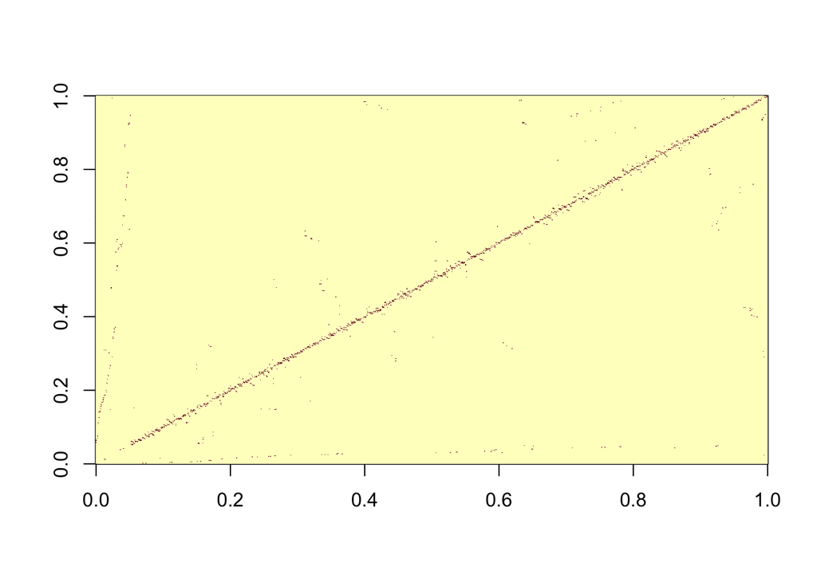

```r
Sanity_w <- W(paracou, 3)
image(Sanity_w)
```

## b.

Determine the $\delta$ vector discussed in the notes for the `paracou` data, using the adults as cases. Use the formula $\delta^T W \delta$ to determine $T_q$ for $q=3$.

```r
Delta <- function(ppp_data, factors = "marks", case) {
  marks <- as.vector(ppp_data[[factors]])
  cord_marks <- ifelse(marks  == case, 1, 0)
  return(as.numeric(cord_marks))
}

TSLR <- function(W, D){
  D <- matrix(D, ncol = 1)
  t(D) %*% W %*% D
}

Sanity_d <- Delta(paracou, case = "adult")
Sanity <- TSLR(Sanity_w, Sanity_d)
Sanity <- as.numeric(Sanity)
```

## c.

Generate 499 data sets under the random labeling hypothesis for the `paracou` data, using the adults as cases. Determine $T_q$ for each simulated data set for $q=3$. Compute the sample mean and variance for the statistics coming from the NULL data (do not include the observed statistic). Compute the Monte Carlo p-value for this test using the observed statistics and the 499 statistics from the simulated data. Make sure to provide your code and clearly indicate the sample mean, sample variance, and Monte Carlo p-value.

We need to create data sets under the RLH, which assumes a constant probability of case-controls assignment in all locations. Lets first do it with one simulated data set then we can build a funciton

```r
#For the one case
Sanity_w <- W(paracou, 3)
Sanity_d <- Delta(paracou, case = "adult")
Sanity <- TSLR(Sanity_w, Sanity_d)
Sanity <- as.numeric(Sanity)


nsim <- 5
data <- paracou
factors <- "marks"
case <- "adult"
nsim <- 100  # number of simulations

T_results <- numeric(nsim)  # initialize a vector to store T_s

for (i in 1:nsim) {
  #SIMULATION OF DATA
  simulated <- data.frame(
    x = paracou$x,
    y = paracou$y,
    marks = sample(paracou$marks)  # keep original labels
  )

  #COMPUTING T STAT FOR EACH
  w <- W(simulated, 3)
  D <- Delta(simulated, case = "adult")  # Delta converts to 0/1 internally
  T_results[i] <- TSLR(w, D)
}
  T_stat <- sum(T_results > Sanity)
```

```r
#actual function
library(progress)

mc_sim_rlh <- function(data, nsim, q, factors, case) {

  # Original t-stat on real data
  W_q <- W(data, q)
  D_q <- Delta(data, factors = factors, case = case)
  T_q <- as.numeric(TSLR(W_q,D_q))

  # Initialize results
  T_results <- numeric(nsim)

  # Create a progress bar with {progress}
  pb <- progress_bar$new(
    format = " Simulating [:bar] :percent | Elapsed: :elapsed | ETA: :eta",
    total = nsim, clear = FALSE, width = 60
  )

  # Simulation loop
  for (i in 1:nsim) {
    # Simulate
    simulated <- data.frame(
      x = data$x,
      y = data$y,
      marks = sample(data$marks)
    )

    # Compute T-stat
    w <- W(simulated, q)
    D <- Delta(simulated, case = case)
    T_results[i] <- TSLR(w, D)

    # Update progress bar
    pb$tick()
  }

  # Compute results
  M_res <- mean(T_results)
  S_res <- sd(T_results)
  V_res <- S_res^2
  T_stat <- sum(T_results > T_q)
  P_val <- ((1+T_stat)/(nsim +1))

  return(list(
    T_Statistic = T_stat,
    Mean = M_res,
    Var = V_res,
    SD = S_res,
    P_value = P_val
  ))
}


#Our result
Result <- mc_sim_rlh(paracou, 499,q = 3,  case = "adult", factors = "marks")
Result
```

```
$T_Statistic
[1] 95

$Mean
[1] 6.817635

$Var
[1] 11.45463

$SD
[1] 3.384469

$P_value
[1] 0.192
```

# Problem 4

Describe how the set of windows considered for the spatial scan method are constructed. More specifically, consider a specific event location. What would the first window be? What would the next window be for that even location? And so on.

So first, it grabs an even location, then it computes a circular scan and computes Twi, which is basically a ratio of the cases inside the window compared to those outside the window. It then uses k nearest neighbors to compute the next circle, including 2 event locations, and computes Twi again, and so on, looking at the proportion of inside the window and outside. This proportion is just the likelihood ratio statistic. It does so iteratively up until all event locations or selected qs have been constructed.